# Proyecto ReneWind Juan Carlos Hernandez Flores full code final

## Planteamiento del problema

### Contexto empresarial

Las fuentes de energía renovables juegan un papel cada vez más importante en la combinación energética global, a medida que aumenta el esfuerzo por reducir el impacto ambiental de la producción de energía.

De todas las alternativas de energía renovable, la energía eólica es una de las tecnologías más desarrolladas a nivel mundial. El Departamento de Energía de EE. UU. ha elaborado una guía para lograr la eficiencia operativa mediante prácticas de mantenimiento predictivo.

El mantenimiento predictivo utiliza información de sensores y métodos de análisis para medir y predecir la degradación y la capacidad futura de los componentes. La idea detrás del mantenimiento predictivo es que los patrones de falla son predecibles y si la falla del componente se puede predecir con precisión y el componente se reemplaza antes de que falle, los costos de operación y mantenimiento serán mucho más bajos.

Los sensores instalados en diferentes máquinas involucradas en el proceso de generación de energía recopilan datos relacionados con varios factores ambientales (temperatura, humedad, velocidad del viento, etc.) y características adicionales relacionadas con varias partes de la turbina eólica (caja de cambios, torre, palas, rotura , etc.).

## Objetivo

“ReneWind” es una empresa que trabaja en la mejora de la maquinaria/procesos involucrados en la producción de energía eólica utilizando el aprendizaje automático y ha recopilado datos de fallas del generador de turbinas eólicas utilizando sensores. Han compartido una versión cifrada de los datos, ya que los datos recopilados a través de sensores son confidenciales (el tipo de datos recopilados varía según las empresas). Los datos tienen 40 predictores, 20000 observaciones en el conjunto de entrenamiento y 5000 en el conjunto de prueba.

El objetivo es construir varios modelos de clasificación, ajustarlos y encontrar el mejor que ayude a identificar fallas para que los generadores puedan repararse antes de fallar para reducir el costo general de mantenimiento. La naturaleza de las predicciones hechas por el modelo de clasificación se traducirá de la siguiente manera:

- Los verdaderos positivos (TP) son fallas correctamente predichas por el modelo. Esto resultará en costos de reparación.
- Los falsos negativos (FN) son fallos reales donde no hay detección por parte del modelo. Esto resultará en costos de reemplazo.
- Los falsos positivos (FP) son detecciones donde no hay falla. Esto resultará en costos de inspección.

Se da que el costo de reparar un generador es mucho menor que el costo de reemplazarlo, y el costo de inspección es menor que el costo de reparación.

"1" en las variables objetivo debe considerarse como "falla" y "0" representa "Sin falla".

## Datos Descripción

- Los datos proporcionados son una versión transformada de los datos originales que se recopilaron mediante sensores.
- Train.csv: se utilizará para entrenar y ajustar modelos.
- Test.csv: solo para probar el rendimiento del mejor modelo final.
- Ambos conjuntos de datos constan de 40 variables predictoras y 1 variable objetivo

## Importación de bibliotecas necesarias

```python
import pandas as pd
import numpy as np


import matplotlib.pyplot as plt
import seaborn as sns


from sklearn.metrics import (
    f1_score,
    accuracy_score,
    recall_score,
    precision_score,
    confusion_matrix,
    roc_auc_score,
)
from sklearn import metrics

from sklearn.model_selection import train_test_split, StratifiedKFold, cross_val_score


from sklearn.preprocessing import StandardScaler, MinMaxScaler, OneHotEncoder


from sklearn.impute import SimpleImputer


from imblearn.over_sampling import SMOTE
from imblearn.under_sampling import RandomUnderSampler


from sklearn.model_selection import RandomizedSearchCV


from sklearn.pipeline import Pipeline
from sklearn.compose import ColumnTransformer


pd.set_option("display.max_columns", None)
pd.set_option("display.max_rows", None)


pd.set_option("display.float_format", lambda x: "%.3f" % x)


from sklearn.linear_model import LogisticRegression
from sklearn.tree import DecisionTreeClassifier
from sklearn.ensemble import (
    AdaBoostClassifier,
    GradientBoostingClassifier,
    RandomForestClassifier,
    BaggingClassifier,
)
from xgboost import XGBClassifier


pd.set_option("display.float_format", lambda x: "%.3f" % x)


import warnings

warnings.filterwarnings("ignore")
```

## Cargando el conjunto de datos

```python
df = pd.read_csv('Train.csv')
df_test = pd.read_csv('Test.csv')
```

```python
data = df.copy()
```

```python
data_test = df_test.copy()
```

## Resumen de datos

- Observaciones
- Controles de cordura

```python
data.head()
```

|  | V1 | V2 | V3 | V4 | V5 | V6 | V7 | V8 | V9 | V10 | V11 | V12 | V13 | V14 | V15 | V16 | V17 | V18 | V19 | V20 | V21 | V22 | V23 | V24 | V25 | V26 | V27 | V28 | V29 | … |
| --- | --- | --- | --- | --- | --- | --- | --- | --- | --- | --- | --- | --- | --- | --- | --- | --- | --- | --- | --- | --- | --- | --- | --- | --- | --- | --- | --- | --- | --- | --- |
| 0 | -4.465 | -4.679 | 3.102 | 0.506 | -0.221 | -2.033 | -2.911 | 0.051 | -1.522 | 3.762 | -5.715 | 0.736 | 0.981 | 1.418 | -3.376 | -3.047 | 0.306 | 2.914 | 2.270 | 4.395 | -2.388 | 0.646 | -1.191 | 3.133 | 0.665 | -2.511 | -0.037 | 0.726 | -3.982 | … |
| 1 | 3.366 | 3.653 | 0.910 | -1.368 | 0.332 | 2.359 | 0.733 | -4.332 | 0.566 | -0.101 | 1.914 | -0.951 | -1.255 | -2.707 | 0.193 | -4.769 | -2.205 | 0.908 | 0.757 | -5.834 | -3.065 | 1.597 | -1.757 | 1.766 | -0.267 | 3.625 | 1.500 | -0.586 | 0.783 | … |
| 2 | -3.832 | -5.824 | 0.634 | -2.419 | -1.774 | 1.017 | -2.099 | -3.173 | -2.082 | 5.393 | -0.771 | 1.107 | 1.144 | 0.943 | -3.164 | -4.248 | -4.039 | 3.689 | 3.311 | 1.059 | -2.143 | 1.650 | -1.661 | 1.680 | -0.451 | -4.551 | 3.739 | 1.134 | -2.034 | … |
| 3 | 1.618 | 1.888 | 7.046 | -1.147 | 0.083 | -1.530 | 0.207 | -2.494 | 0.345 | 2.119 | -3.053 | 0.460 | 2.705 | -0.636 | -0.454 | -3.174 | -3.404 | -1.282 | 1.582 | -1.952 | -3.517 | -1.206 | -5.628 | -1.818 | 2.124 | 5.295 | 4.748 | -2.309 | -3.963 | … |
| 4 | -0.111 | 3.872 | -3.758 | -2.983 | 3.793 | 0.545 | 0.205 | 4.849 | -1.855 | -6.220 | 1.998 | 4.724 | 0.709 | -1.989 | -2.633 | 4.184 | 2.245 | 3.734 | -6.313 | -5.380 | -0.887 | 2.062 | 9.446 | 4.490 | -3.945 | 4.582 | -8.780 | -3.383 | 5.107 | … |

```python
data_test.tail()
```

|  | V1 | V2 | V3 | V4 | V5 | V6 | V7 | V8 | V9 | V10 | V11 | V12 | V13 | V14 | V15 | V16 | V17 | V18 | V19 | V20 | V21 | V22 | V23 | V24 | V25 | V26 | V27 | V28 | V29 | … |
| --- | --- | --- | --- | --- | --- | --- | --- | --- | --- | --- | --- | --- | --- | --- | --- | --- | --- | --- | --- | --- | --- | --- | --- | --- | --- | --- | --- | --- | --- | --- |
| 4995 | -5.120 | 1.635 | 1.251 | 4.036 | 3.291 | -2.932 | -1.329 | 1.754 | -2.985 | 1.249 | -6.878 | 3.715 | -2.512 | -1.395 | -2.554 | -2.197 | 4.772 | 2.403 | 3.792 | 0.487 | -2.028 | 1.778 | 3.668 | 11.375 | -1.977 | 2.252 | -7.319 | 1.907 | -3.734 | … |
| 4996 | -5.172 | 1.172 | 1.579 | 1.220 | 2.530 | -0.669 | -2.618 | -2.001 | 0.634 | -0.579 | -3.671 | 0.460 | 3.321 | -1.075 | -7.113 | -4.356 | -0.001 | 3.698 | -0.846 | -0.222 | -3.645 | 0.736 | 0.926 | 3.278 | -2.277 | 4.458 | -4.543 | -1.348 | -1.779 | … |
| 4997 | -1.114 | -0.404 | -1.765 | -5.879 | 3.572 | 3.711 | -2.483 | -0.308 | -0.922 | -2.999 | -0.112 | -1.977 | -1.623 | -0.945 | -2.735 | -0.813 | 0.610 | 8.149 | -9.199 | -3.872 | -0.296 | 1.468 | 2.884 | 2.792 | -1.136 | 1.198 | -4.342 | -2.869 | 4.124 | … |
| 4998 | -1.703 | 0.615 | 6.221 | -0.104 | 0.956 | -3.279 | -1.634 | -0.104 | 1.388 | -1.066 | -7.970 | 2.262 | 3.134 | -0.486 | -3.498 | -4.562 | 3.136 | 2.536 | -0.792 | 4.398 | -4.073 | -0.038 | -2.371 | -1.542 | 2.908 | 3.215 | -0.169 | -1.541 | -4.724 | … |
| 4999 | -0.604 | 0.960 | -0.721 | 8.230 | -1.816 | -2.276 | -2.575 | -1.041 | 4.130 | -2.731 | -3.292 | -1.674 | 0.465 | -1.646 | -5.263 | -7.988 | 6.480 | 0.226 | 4.963 | 6.752 | -6.306 | 3.271 | 1.897 | 3.271 | -0.637 | -0.925 | -6.759 | 2.990 | -0.814 | … |

```python
print("There are", df.shape[0], 'rows and', df.shape[1], "columns.")
```

```
There are 20000 rows and 41 columns.
```

```python
print("There are", df_test.shape[0], 'rows and', df_test.shape[1], "columns.")
```

```
There are 5000 rows and 41 columns.
```

```python
data.info()
```

```
<class 'pandas.core.frame.DataFrame'>
RangeIndex: 20000 entries, 0 to 19999
Data columns (total 41 columns):
 #   Column  Non-Null Count  Dtype
---  ------  --------------  -----
 0   V1      19982 non-null  float64
 1   V2      19982 non-null  float64
 2   V3      20000 non-null  float64
 3   V4      20000 non-null  float64
 4   V5      20000 non-null  float64
 5   V6      20000 non-null  float64
 6   V7      20000 non-null  float64
 7   V8      20000 non-null  float64
 8   V9      20000 non-null  float64
 9   V10     20000 non-null  float64
```

[output cut: 33 more lines]

```python
data_test.info()
```

```
<class 'pandas.core.frame.DataFrame'>
RangeIndex: 5000 entries, 0 to 4999
Data columns (total 41 columns):
 #   Column  Non-Null Count  Dtype
---  ------  --------------  -----
 0   V1      4995 non-null   float64
 1   V2      4994 non-null   float64
 2   V3      5000 non-null   float64
 3   V4      5000 non-null   float64
 4   V5      5000 non-null   float64
 5   V6      5000 non-null   float64
 6   V7      5000 non-null   float64
 7   V8      5000 non-null   float64
 8   V9      5000 non-null   float64
 9   V10     5000 non-null   float64
```

[output cut: 33 more lines]

Aqui podemos visualizar el tipo de datos que hay en los df y la cantidad de observaciones que tienen las variables.

```python
data.isnull().sum()
```

```
V1        18
V2        18
V3         0
V4         0
V5         0
V6         0
V7         0
V8         0
V9         0
V10        0
V11        0
V12        0
V13        0
V14        0
V15        0
V16        0
V17        0
V18        0
V19        0
V20        0
V21        0
V22        0
V23        0
V24        0
V25        0
V26        0
V27        0
V28        0
V29        0
V30        0
V31        0
V32        0
V33        0
V34        0
V35        0
V36        0
V37        0
V38        0
V39        0
V40        0
Target     0
dtype: int64
```

```python
data_test.isnull().sum()
```

```
V1        5
V2        6
V3        0
V4        0
V5        0
V6        0
V7        0
V8        0
V9        0
V10       0
V11       0
V12       0
V13       0
V14       0
V15       0
V16       0
V17       0
V18       0
V19       0
V20       0
V21       0
V22       0
V23       0
V24       0
V25       0
V26       0
V27       0
V28       0
V29       0
V30       0
V31       0
V32       0
V33       0
V34       0
V35       0
V36       0
V37       0
V38       0
V39       0
V40       0
Target    0
dtype: int64
```

Podemos ver que ambos df cuentan con valores perdidos.

```python
data.describe(include ='all').T
```

|  | count | mean | std | min | 25% | 50% | 75% | max |
| --- | --- | --- | --- | --- | --- | --- | --- | --- |
| V1 | 19982.000 | -0.272 | 3.442 | -11.876 | -2.737 | -0.748 | 1.840 | 15.493 |
| V2 | 19982.000 | 0.440 | 3.151 | -12.320 | -1.641 | 0.472 | 2.544 | 13.089 |
| V3 | 20000.000 | 2.485 | 3.389 | -10.708 | 0.207 | 2.256 | 4.566 | 17.091 |
| V4 | 20000.000 | -0.083 | 3.432 | -15.082 | -2.348 | -0.135 | 2.131 | 13.236 |
| V5 | 20000.000 | -0.054 | 2.105 | -8.603 | -1.536 | -0.102 | 1.340 | 8.134 |
| V6 | 20000.000 | -0.995 | 2.041 | -10.227 | -2.347 | -1.001 | 0.380 | 6.976 |
| V7 | 20000.000 | -0.879 | 1.762 | -7.950 | -2.031 | -0.917 | 0.224 | 8.006 |
| V8 | 20000.000 | -0.548 | 3.296 | -15.658 | -2.643 | -0.389 | 1.723 | 11.679 |
| V9 | 20000.000 | -0.017 | 2.161 | -8.596 | -1.495 | -0.068 | 1.409 | 8.138 |
| V10 | 20000.000 | -0.013 | 2.193 | -9.854 | -1.411 | 0.101 | 1.477 | 8.108 |
| V11 | 20000.000 | -1.895 | 3.124 | -14.832 | -3.922 | -1.921 | 0.119 | 11.826 |
| V12 | 20000.000 | 1.605 | 2.930 | -12.948 | -0.397 | 1.508 | 3.571 | 15.081 |
| V13 | 20000.000 | 1.580 | 2.875 | -13.228 | -0.224 | 1.637 | 3.460 | 15.420 |
| V14 | 20000.000 | -0.951 | 1.790 | -7.739 | -2.171 | -0.957 | 0.271 | 5.671 |
| V15 | 20000.000 | -2.415 | 3.355 | -16.417 | -4.415 | -2.383 | -0.359 | 12.246 |
| V16 | 20000.000 | -2.925 | 4.222 | -20.374 | -5.634 | -2.683 | -0.095 | 13.583 |
| V17 | 20000.000 | -0.134 | 3.345 | -14.091 | -2.216 | -0.015 | 2.069 | 16.756 |
| V18 | 20000.000 | 1.189 | 2.592 | -11.644 | -0.404 | 0.883 | 2.572 | 13.180 |
| V19 | 20000.000 | 1.182 | 3.397 | -13.492 | -1.050 | 1.279 | 3.493 | 13.238 |
| V20 | 20000.000 | 0.024 | 3.669 | -13.923 | -2.433 | 0.033 | 2.512 | 16.052 |
| V21 | 20000.000 | -3.611 | 3.568 | -17.956 | -5.930 | -3.533 | -1.266 | 13.840 |
| V22 | 20000.000 | 0.952 | 1.652 | -10.122 | -0.118 | 0.975 | 2.026 | 7.410 |
| V23 | 20000.000 | -0.366 | 4.032 | -14.866 | -3.099 | -0.262 | 2.452 | 14.459 |
| V24 | 20000.000 | 1.134 | 3.912 | -16.387 | -1.468 | 0.969 | 3.546 | 17.163 |
| V25 | 20000.000 | -0.002 | 2.017 | -8.228 | -1.365 | 0.025 | 1.397 | 8.223 |
| V26 | 20000.000 | 1.874 | 3.435 | -11.834 | -0.338 | 1.951 | 4.130 | 16.836 |
| V27 | 20000.000 | -0.612 | 4.369 | -14.905 | -3.652 | -0.885 | 2.189 | 17.560 |
| V28 | 20000.000 | -0.883 | 1.918 | -9.269 | -2.171 | -0.891 | 0.376 | 6.528 |
| V29 | 20000.000 | -0.986 | 2.684 | -12.579 | -2.787 | -1.176 | 0.630 | 10.722 |
| V30 | 20000.000 | -0.016 | 3.005 | -14.796 | -1.867 | 0.184 | 2.036 | 12.506 |
| V31 | 20000.000 | 0.487 | 3.461 | -13.723 | -1.818 | 0.490 | 2.731 | 17.255 |
| V32 | 20000.000 | 0.304 | 5.500 | -19.877 | -3.420 | 0.052 | 3.762 | 23.633 |
| V33 | 20000.000 | 0.050 | 3.575 | -16.898 | -2.243 | -0.066 | 2.255 | 16.692 |
| V34 | 20000.000 | -0.463 | 3.184 | -17.985 | -2.137 | -0.255 | 1.437 | 14.358 |
| V35 | 20000.000 | 2.230 | 2.937 | -15.350 | 0.336 | 2.099 | 4.064 | 15.291 |
| V36 | 20000.000 | 1.515 | 3.801 | -14.833 | -0.944 | 1.567 | 3.984 | 19.330 |
| V37 | 20000.000 | 0.011 | 1.788 | -5.478 | -1.256 | -0.128 | 1.176 | 7.467 |
| V38 | 20000.000 | -0.344 | 3.948 | -17.375 | -2.988 | -0.317 | 2.279 | 15.290 |
| V39 | 20000.000 | 0.891 | 1.753 | -6.439 | -0.272 | 0.919 | 2.058 | 7.760 |
| V40 | 20000.000 | -0.876 | 3.012 | -11.024 | -2.940 | -0.921 | 1.120 | 10.654 |
| Target | 20000.000 | 0.056 | 0.229 | 0.000 | 0.000 | 0.000 | 0.000 | 1.000 |

```python
data_test.describe(include = 'all').T
```

|  | count | mean | std | min | 25% | 50% | 75% | max |
| --- | --- | --- | --- | --- | --- | --- | --- | --- |
| V1 | 4995.000 | -0.278 | 3.466 | -12.382 | -2.744 | -0.765 | 1.831 | 13.504 |
| V2 | 4994.000 | 0.398 | 3.140 | -10.716 | -1.649 | 0.427 | 2.444 | 14.079 |
| V3 | 5000.000 | 2.552 | 3.327 | -9.238 | 0.315 | 2.260 | 4.587 | 15.315 |
| V4 | 5000.000 | -0.049 | 3.414 | -14.682 | -2.293 | -0.146 | 2.166 | 12.140 |
| V5 | 5000.000 | -0.080 | 2.111 | -7.712 | -1.615 | -0.132 | 1.341 | 7.673 |
| V6 | 5000.000 | -1.042 | 2.005 | -8.924 | -2.369 | -1.049 | 0.308 | 5.068 |
| V7 | 5000.000 | -0.908 | 1.769 | -8.124 | -2.054 | -0.940 | 0.212 | 7.616 |
| V8 | 5000.000 | -0.575 | 3.332 | -12.253 | -2.642 | -0.358 | 1.713 | 10.415 |
| V9 | 5000.000 | 0.030 | 2.174 | -6.785 | -1.456 | -0.080 | 1.450 | 8.851 |
| V10 | 5000.000 | 0.019 | 2.145 | -8.171 | -1.353 | 0.166 | 1.511 | 6.599 |
| V11 | 5000.000 | -2.009 | 3.112 | -13.152 | -4.050 | -2.043 | 0.044 | 9.956 |
| V12 | 5000.000 | 1.576 | 2.907 | -8.164 | -0.450 | 1.488 | 3.563 | 12.984 |
| V13 | 5000.000 | 1.622 | 2.883 | -11.548 | -0.126 | 1.719 | 3.465 | 12.620 |
| V14 | 5000.000 | -0.921 | 1.803 | -7.814 | -2.111 | -0.896 | 0.272 | 5.734 |
| V15 | 5000.000 | -2.452 | 3.387 | -15.286 | -4.479 | -2.417 | -0.433 | 11.673 |
| V16 | 5000.000 | -3.019 | 4.264 | -20.986 | -5.648 | -2.774 | -0.178 | 13.976 |
| V17 | 5000.000 | -0.104 | 3.337 | -13.418 | -2.228 | 0.047 | 2.112 | 19.777 |
| V18 | 5000.000 | 1.196 | 2.586 | -12.214 | -0.409 | 0.881 | 2.604 | 13.642 |
| V19 | 5000.000 | 1.210 | 3.385 | -14.170 | -1.026 | 1.296 | 3.526 | 12.428 |
| V20 | 5000.000 | 0.138 | 3.657 | -13.720 | -2.325 | 0.193 | 2.540 | 13.871 |
| V21 | 5000.000 | -3.664 | 3.578 | -16.341 | -5.944 | -3.663 | -1.330 | 11.047 |
| V22 | 5000.000 | 0.962 | 1.640 | -6.740 | -0.048 | 0.986 | 2.029 | 7.505 |
| V23 | 5000.000 | -0.422 | 4.057 | -14.422 | -3.163 | -0.279 | 2.426 | 13.181 |
| V24 | 5000.000 | 1.089 | 3.968 | -12.316 | -1.623 | 0.913 | 3.537 | 17.806 |
| V25 | 5000.000 | 0.061 | 2.010 | -6.770 | -1.298 | 0.077 | 1.428 | 6.557 |
| V26 | 5000.000 | 1.847 | 3.400 | -11.414 | -0.242 | 1.917 | 4.156 | 17.528 |
| V27 | 5000.000 | -0.552 | 4.403 | -13.177 | -3.663 | -0.872 | 2.247 | 17.290 |
| V28 | 5000.000 | -0.868 | 1.926 | -7.933 | -2.160 | -0.931 | 0.421 | 7.416 |
| V29 | 5000.000 | -1.096 | 2.655 | -9.988 | -2.861 | -1.341 | 0.522 | 14.039 |
| V30 | 5000.000 | -0.119 | 3.023 | -12.438 | -1.997 | 0.112 | 1.946 | 10.315 |
| V31 | 5000.000 | 0.469 | 3.446 | -11.263 | -1.822 | 0.486 | 2.779 | 12.559 |
| V32 | 5000.000 | 0.233 | 5.586 | -17.244 | -3.556 | -0.077 | 3.752 | 26.539 |
| V33 | 5000.000 | -0.080 | 3.539 | -14.904 | -2.348 | -0.160 | 2.099 | 13.324 |
| V34 | 5000.000 | -0.393 | 3.166 | -14.700 | -2.010 | -0.172 | 1.465 | 12.146 |
| V35 | 5000.000 | 2.211 | 2.948 | -12.261 | 0.322 | 2.112 | 4.032 | 13.489 |
| V36 | 5000.000 | 1.595 | 3.775 | -12.736 | -0.866 | 1.703 | 4.104 | 17.116 |
| V37 | 5000.000 | 0.023 | 1.785 | -5.079 | -1.241 | -0.110 | 1.238 | 6.810 |
| V38 | 5000.000 | -0.406 | 3.969 | -15.335 | -2.984 | -0.381 | 2.288 | 13.065 |
| V39 | 5000.000 | 0.939 | 1.717 | -5.451 | -0.208 | 0.959 | 2.131 | 7.182 |
| V40 | 5000.000 | -0.932 | 2.978 | -10.076 | -2.987 | -1.003 | 1.080 | 8.698 |
| Target | 5000.000 | 0.056 | 0.231 | 0.000 | 0.000 | 0.000 | 0.000 | 1.000 |

## Análisis exploratorio de datos (EDA)

### Trazado de histogramas y diagramas de caja para todas las variables

```python
# function to plot a boxplot and a histogram along the same scale.


def histogram_boxplot(data, feature, figsize=(12, 7), kde=False, bins=None):
    """
    Boxplot and histogram combined

    data: dataframe
    feature: dataframe column
    figsize: size of figure (default (12,7))
    kde: whether to the show density curve (default False)
    bins: number of bins for histogram (default None)
    """
    f2, (ax_box2, ax_hist2) = plt.subplots(
        nrows=2,  # Number of rows of the subplot grid= 2
        sharex=True,  # x-axis will be shared among all subplots
        gridspec_kw={"height_ratios": (0.25, 0.75)},
        figsize=figsize,
    )  # creating the 2 subplots
    sns.boxplot(
        data=data, x=feature, ax=ax_box2, showmeans=True, color="violet"
    )  # boxplot will be created and a star will indicate the mean value of the column
    sns.histplot(
        data=data, x=feature, kde=kde, ax=ax_hist2, bins=bins, palette="winter"
    ) if bins else sns.histplot(
        data=data, x=feature, kde=kde, ax=ax_hist2
    )  # For histogram
    ax_hist2.axvline(
        data[feature].mean(), color="green", linestyle="--"
    )  # Add mean to the histogram
    ax_hist2.axvline(
        data[feature].median(), color="black", linestyle="-"
    )  # Add median to the histogram
```

### Trazado de todas las características de una sola vez

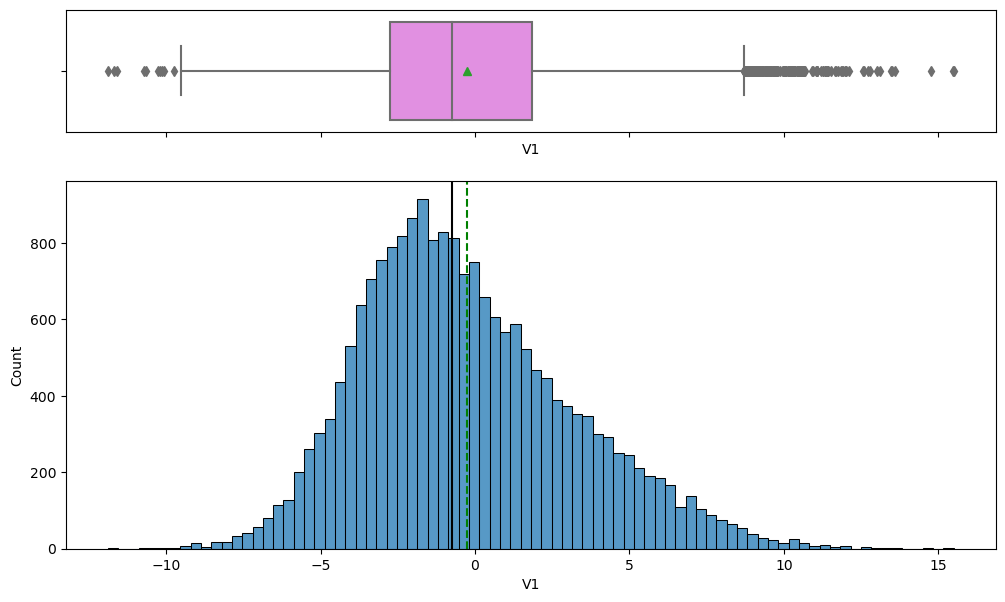

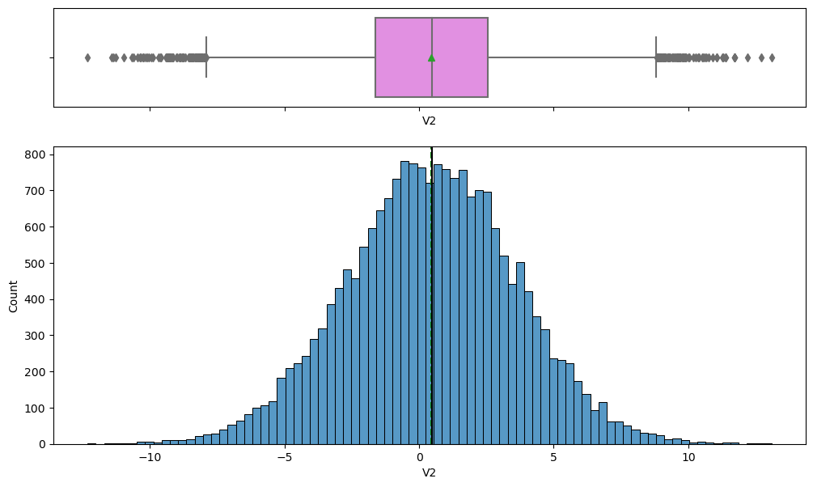

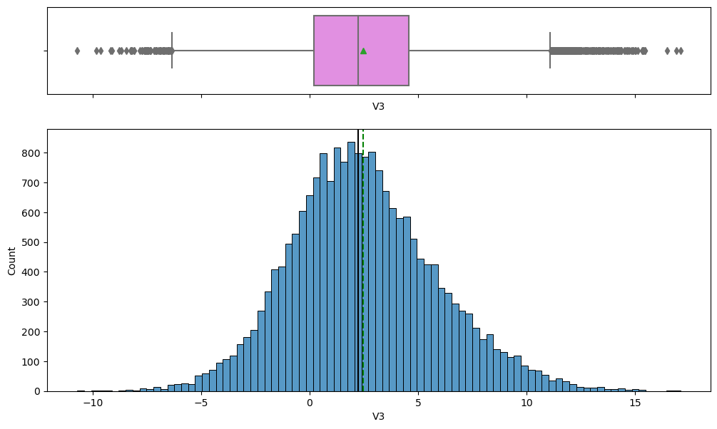

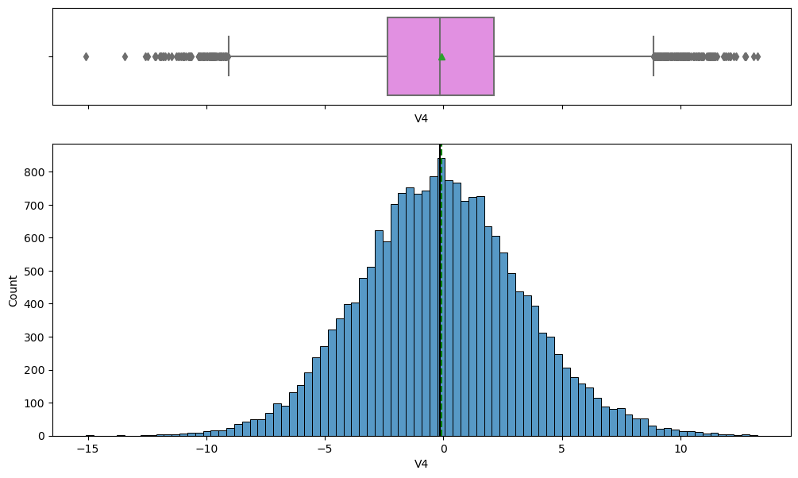

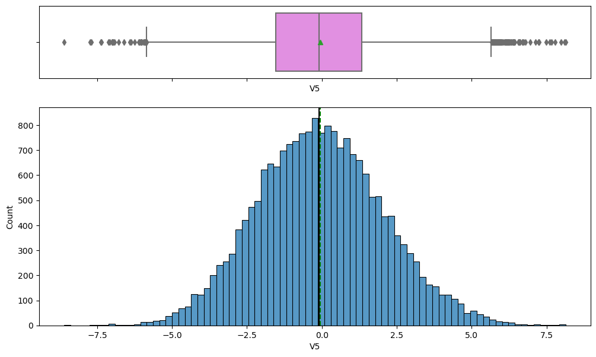

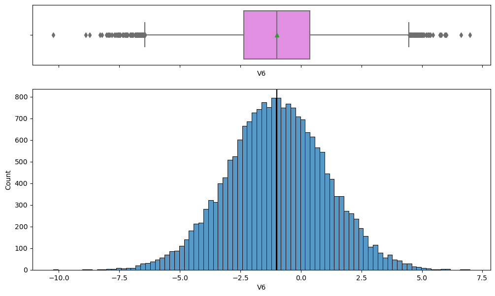

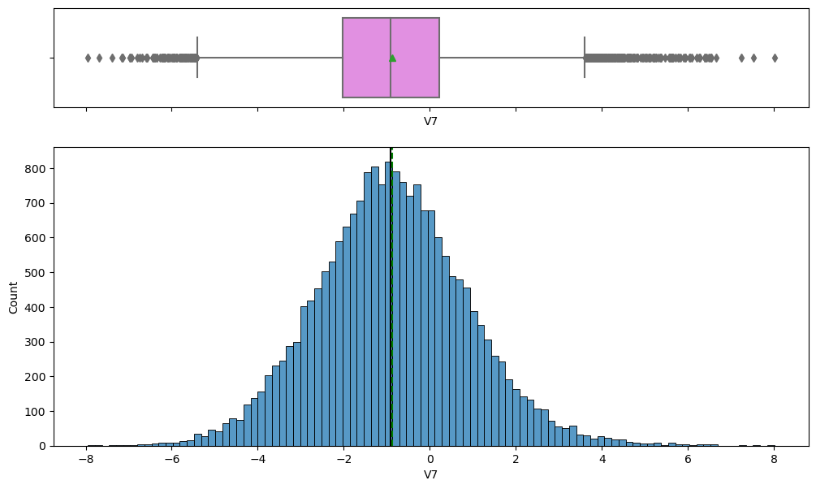

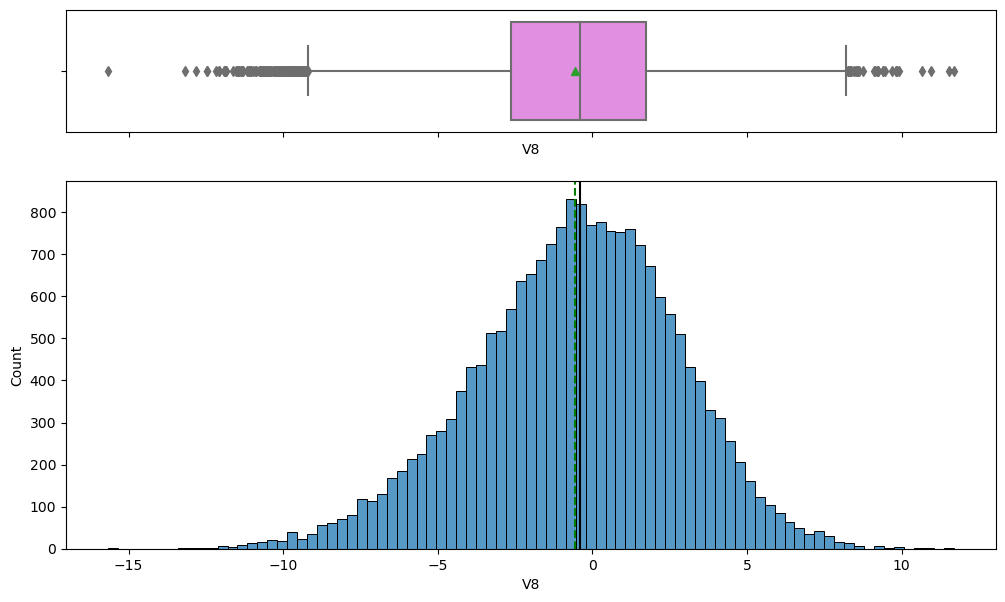

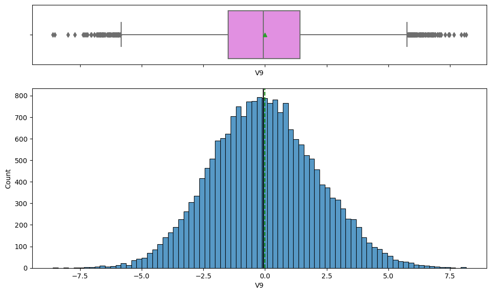

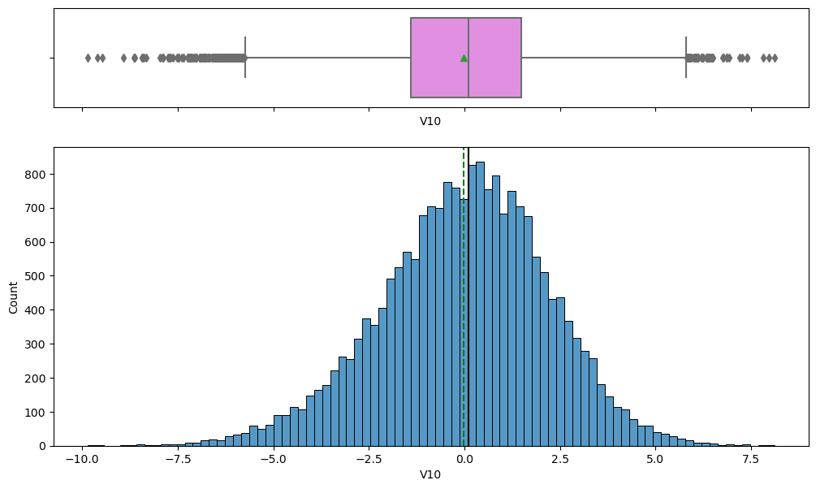

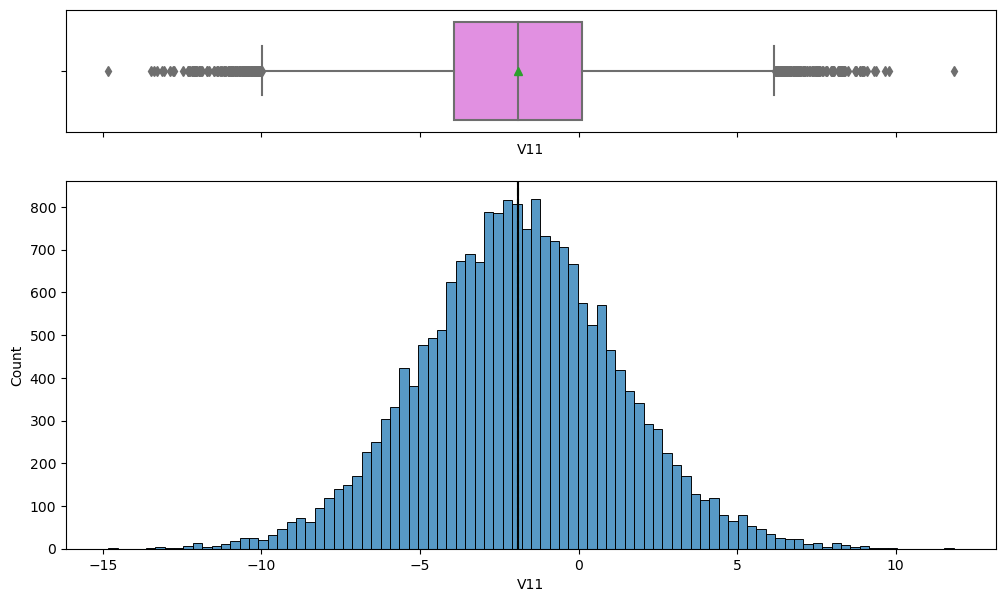

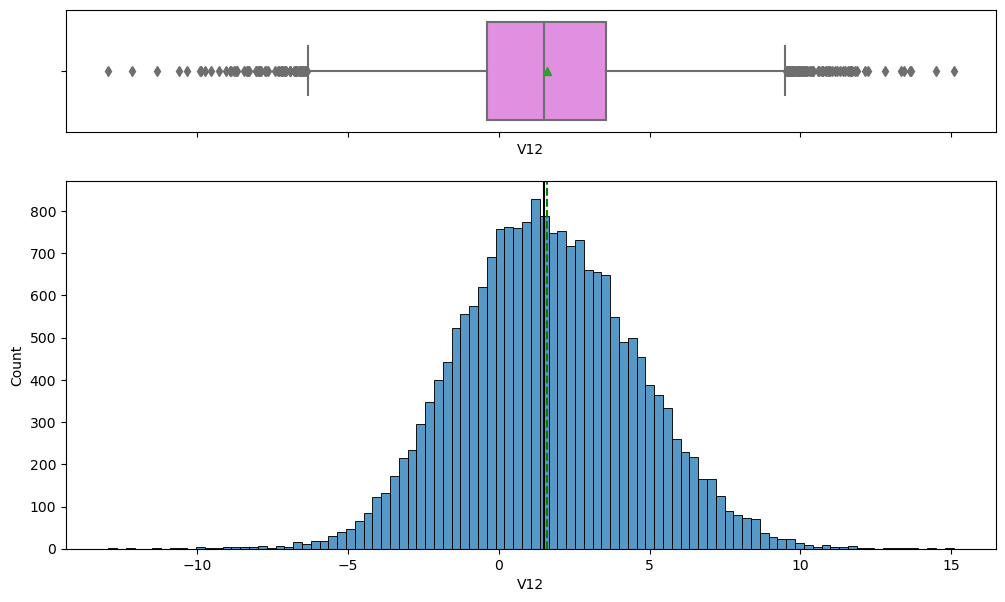

[29 more figures not shown]

```python
for feature in df.columns:
    histogram_boxplot(df, feature, figsize=(12, 7), kde=False, bins=None) ## Please change the dataframe name as you define while reading the data
```

### Observaciones

- Distribución: La mayoría de las características presentan una distribución medianamente simétrica, aunque hay algunas asimetrías notables.
- Valores Atípicos: Muchas características muestran valores atípicos significativos que podrían influir en el rendimiento del modelo.
- Desequilibrio del Target: La variable objetivo está desequilibrada, con una preponderancia hacia la clase "0".
- Consistencia: Hay patrones consistentes en la distribución de valores a través de las características.

## Preprocesamiento de datos

```python
X = data.drop(["Target"], axis=1)
y = data["Target"]
```

```python
X_train, X_val, y_train, y_val = train_test_split(
    X, y, test_size=0.25, random_state=1, stratify=y
)
print(X_train.shape, X_val.shape)
```

```
(15000, 40) (5000, 40)
```

```python
print("Number of rows in train data =", X_train.shape[0])
print("Number of rows in validation data =", X_val.shape[0])
```

```
Number of rows in train data = 15000
Number of rows in validation data = 5000
```

```python
X_test = data_test.drop(["Target"], axis=1)
y_test = data_test["Target"]
```

```python
print("Number of rows in test data =", X_test.shape[0])
```

```
Number of rows in test data = 5000
```

## Imputación de valor faltante

```python
imputer = SimpleImputer(strategy="median") #imputacion de valores faltantes por medio de la mediana
```

```python
X_train = pd.DataFrame(imputer.fit_transform(X_train), columns=X_train.columns)


X_val = pd.DataFrame(imputer.transform(X_val), columns=X_train.columns)


X_test = pd.DataFrame(imputer.transform(X_test), columns=X_train.columns)
```

```python
print(X_train.isna().sum())
print("-" * 30)
print(X_val.isna().sum())
print("-" * 30)
print(X_test.isna().sum())
```

```
V1     0
V2     0
V3     0
V4     0
V5     0
V6     0
V7     0
V8     0
V9     0
V10    0
V11    0
V12    0
V13    0
V14    0
V15    0
V16    0
V17    0
V18    0
V19    0
V20    0
V21    0
V22    0
V23    0
V24    0
V25    0
V26    0
V27    0
V28    0
V29    0
V30    0
V31    0
V32    0
V33    0
V34    0
V35    0
V36    0
V37    0
V38    0
V39    0
V40    0
```

[output cut: 70 more lines]

```
V27    0
V28    0
V29    0
V30    0
V31    0
V32    0
V33    0
V34    0
V35    0
V36    0
V37    0
V38    0
V39    0
V40    0
dtype: int64
```

Podemos visualizar que los valores faltantes han sido correctamente imputados.

## Construcción del modelo

### Criterio de evaluación del modelo

La naturaleza de las predicciones hechas por el modelo de clasificación se traducirá de la siguiente manera:

- Los verdaderos positivos (TP) son fallas correctamente predichas por el modelo.
- Los falsos negativos (FN) son fallas reales en un generador donde no hay detección por modelo.
- Los falsos positivos (FP) son detecciones de fallas en un generador donde no hay falla.

**¿Qué métrica optimizar?**

- Necesitamos elegir la métrica que garantizará que el modelo prediga correctamente la cantidad máxima de fallas del generador.
- Queremos maximizar el valor de *recall*, ya que cuanto mayor sea, mayores serán las posibilidades de minimizar los falsos negativos.
- Queremos minimizar los falsos negativos porque si un modelo predice que una máquina no fallará cuando la habrá, aumentará el costo de mantenimiento.

**Definamos una función para generar diferentes métricas (incluido el valor *recall*) en el conjunto de prueba y entrenamiento y una función para mostrar la matriz de confusión para que no tengamos que usar el mismo código repetitivamente mientras evaluamos modelos.**

```python
# defining a function to compute different metrics to check performance of a classification model built using sklearn
def model_performance_classification_sklearn(model, predictors, target):
    """
    Function to compute different metrics to check classification model performance

    model: classifier
    predictors: independent variables
    target: dependent variable
    """

    # predicting using the independent variables
    pred = model.predict(predictors)

    acc = accuracy_score(target, pred)  # to compute Accuracy
    recall = recall_score(target, pred)  # to compute Recall
    precision = precision_score(target, pred)  # to compute Precision
    f1 = f1_score(target, pred)  # to compute F1-score

    # creating a dataframe of metrics
    df_perf = pd.DataFrame(
        {
            "Accuracy": acc,
            "Recall": recall,
            "Precision": precision,
            "F1": f1

        },
        index=[0],
    )

    return df_perf
```

### Definición de la puntuación que se utilizará para la validación cruzada y el ajuste de hiperparámetros

- Queremos reducir los falsos negativos e intentaremos maximizar "recall".
- Para maximizar Recall, podemos usar Recall como la **puntuación (*score*)** en validación cruzada y ajuste de hiperparámetros.

```python
# Type of scoring used to compare parameter combinations
scorer = metrics.make_scorer(metrics.recall_score)
```

### Construcción de modelos con datos originales

```python
models = []  # Empty list to store all the models

# Appending models into the list
models.append(("Bagging", BaggingClassifier(random_state=1)))
models.append(("Random forest", RandomForestClassifier(random_state=1)))
models.append(("GBM", GradientBoostingClassifier(random_state=1)))
models.append(("Adaboost", AdaBoostClassifier(random_state=1)))
models.append(("Xgboost", XGBClassifier(random_state=1, eval_metric="logloss")))
models.append(("dtree", DecisionTreeClassifier(random_state=1)))
models.append(('Logistic Regression', LogisticRegression()))


results1 = []  # Empty list to store all model's CV scores
names = []  # Empty list to store name of the models


# loop through all models to get the mean cross validated score
print("\n" "Cross-Validation performance on training dataset:" "\n")

for name, model in models:
    kfold = StratifiedKFold(
        n_splits=5, shuffle=True, random_state=1
    )  # Setting number of splits equal to 5
    cv_result = cross_val_score(
        estimator=model, X=X_train, y=y_train, scoring=scorer, cv=kfold
    )
    results1.append(cv_result)
    names.append(name)
    print("{}: {}".format(name, cv_result.mean()))

print("\n" "Validation Performance:" "\n")

for name, model in models:
    model.fit(X_train, y_train)
    scores = recall_score(y_val, model.predict(X_val))
    print("{}: {}".format(name, scores))
```

```
Cross-Validation performance on training dataset:

Bagging: 0.7210807301060529
Random forest: 0.7235192266070268
GBM: 0.7066661857008874
Adaboost: 0.6309140754635308
Xgboost: 0.8100497799581561
dtree: 0.6982829521679532
Logistic Regression: 0.4927566553639709

Validation Performance:

Bagging: 0.7302158273381295
Random forest: 0.7266187050359713
GBM: 0.7230215827338129
Adaboost: 0.6762589928057554
Xgboost: 0.8309352517985612
dtree: 0.7050359712230215
Logistic Regression: 0.48201438848920863
```

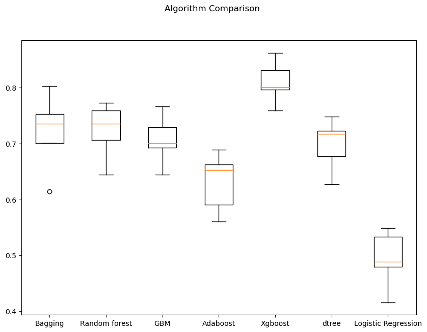

```python
fig = plt.figure(figsize=(10, 7))

fig.suptitle("Algorithm Comparison")
ax = fig.add_subplot(111)

plt.boxplot(results1)
ax.set_xticklabels(names)

plt.show()
```

## Observaciones

> Observaciones de los Modelos con Datos Originales:
- Mejor Rendimiento:

Noté que XGBoost se destacó claramente, obteniendo un recall de 0.8100 en el conjunto de entrenamiento y 0.8309 en el conjunto de validación.

- Rendimiento Medio:

Los modelos Bagging, Random Forest y GBM mostraron un rendimiento bastante aceptable. Específicamente, Bagging y Random Forest tuvieron un desempeño ligeramente superior a GBM.

- Rendimiento Inferior:

Observé que Adaboost, Decision Tree y Logistic Regression no se desempeñaron tan bien, con Logistic Regression mostrando el recall más bajo.

La gráfica refuerza la idea de que XGBoost es el modelo más prometedor para este conjunto de datos. Es notable cómo Logistic Regression tiene un rendimiento significativamente más bajo que los otros modelos, lo que puede sugerir que las relaciones en los datos no son lineales o que otros modelos pueden capturar la complejidad de los datos de manera más efectiva. La consistencia en el rendimiento entre el conjunto de entrenamiento y el conjunto de validación para cada modelo indica que no hay un sobreajuste significativo.

### Creación de modelos con datos sobremuestreados

```python
print("Before OverSampling, counts of label '1': {}".format(sum(y_train == 1)))
print("Before OverSampling, counts of label '0': {} \n".format(sum(y_train == 0)))

# Synthetic Minority Over Sampling Technique
sm = SMOTE(sampling_strategy=1, k_neighbors=5, random_state=1)
X_train_over, y_train_over = sm.fit_resample(X_train, y_train)


print("After OverSampling, counts of label '1': {}".format(sum(y_train_over == 1)))
print("After OverSampling, counts of label '0': {} \n".format(sum(y_train_over == 0)))


print("After OverSampling, the shape of train_X: {}".format(X_train_over.shape))
print("After OverSampling, the shape of train_y: {} \n".format(y_train_over.shape))
```

```
Before OverSampling, counts of label '1': 832
Before OverSampling, counts of label '0': 14168

After OverSampling, counts of label '1': 14168
After OverSampling, counts of label '0': 14168

After OverSampling, the shape of train_X: (28336, 40)
After OverSampling, the shape of train_y: (28336,)
```

```python
models = []  # Empty list to store all the models

# Appending models into the list
models.append(("Bagging", BaggingClassifier(random_state=1)))
models.append(("Random forest", RandomForestClassifier(random_state=1)))
models.append(("GBM", GradientBoostingClassifier(random_state=1)))
models.append(("Adaboost", AdaBoostClassifier(random_state=1)))
models.append(("Xgboost", XGBClassifier(random_state=1, eval_metric="logloss")))
models.append(("dtree", DecisionTreeClassifier(random_state=1)))
models.append(('Logistic Regression', LogisticRegression()))


results1 = []  # Empty list to store all model's CV scores
names = []  # Empty list to store name of the models


# loop through all models to get the mean cross validated score
print("\n" "Cross-Validation performance on training dataset:" "\n")

for name, model in models:
    kfold = StratifiedKFold(
        n_splits=5, shuffle=True, random_state=1
    )  # Setting number of splits equal to 5
    cv_result = cross_val_score(
        estimator=model, X=X_train_over, y=y_train_over, scoring=scorer, cv=kfold
    )
    results1.append(cv_result)
    names.append(name)
    print("{}: {}".format(name, cv_result.mean()))

print("\n" "Validation Performance:" "\n")

for name, model in models:
    model.fit(X_train_over,y_train_over)
    scores = recall_score(y_val, model.predict(X_val))
    print("{}: {}".format(name, scores))
```

```
Cross-Validation performance on training dataset:

Bagging: 0.9762141471581656
Random forest: 0.9839075260047615
GBM: 0.9256068151319724
Adaboost: 0.8978689011775473
Xgboost: 0.9891305241357218
dtree: 0.9720494245534969
Logistic Regression: 0.883963699328486

Validation Performance:

Bagging: 0.8345323741007195
Random forest: 0.8489208633093526
GBM: 0.8776978417266187
Adaboost: 0.8561151079136691
Xgboost: 0.8669064748201439
dtree: 0.7769784172661871
Logistic Regression: 0.8489208633093526
```

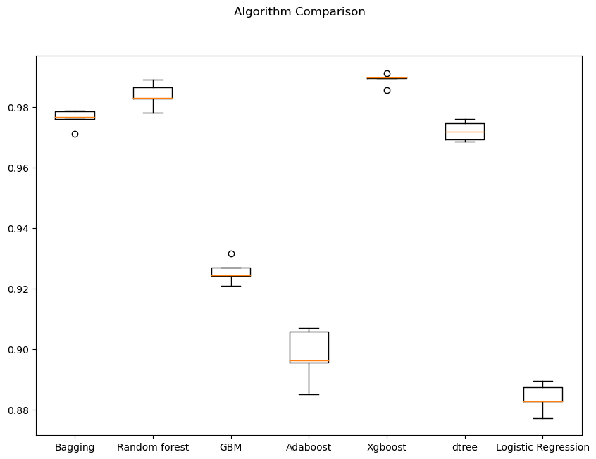

```python
fig = plt.figure(figsize=(10, 7))

fig.suptitle("Algorithm Comparison")
ax = fig.add_subplot(111)

plt.boxplot(results1)
ax.set_xticklabels(names)

plt.show()
```

## Observaciones

> Observaciones de los Modelos con Datos Sobremuestreados:
- Entrenamiento:

XGBoost lidera con un recall de 0.9891. Random Forest también muestra un alto recall de 0.9839.

- Validación:

Aunque XGBoost tuvo un rendimiento destacado en entrenamiento, en validación fue superado por GBM con un recall de 0.8777. Adaboost y XGBoost siguen con recalls de 0.8561 y 0.8669, respectivamente. Diferencia en Rendimiento:

Modelos como Bagging, Random Forest y XGBoost muestran signos de sobreajuste, con un alto rendimiento en entrenamiento pero una reducción en validación. Con datos sobremuestreados, Logistic Regression mejoró notablemente en comparación con los datos originales.

### Creación de modelos con datos submuestreados

```python
rus = RandomUnderSampler(random_state=1, sampling_strategy=1)
X_train_un, y_train_un = rus.fit_resample(X_train, y_train)


print("Before UnderSampling, counts of label '1': {}".format(sum(y_train == 1)))
print("Before UnderSampling, counts of label '0': {} \n".format(sum(y_train == 0)))


print("After UnderSampling, counts of label '1': {}".format(sum(y_train_un == 1)))
print("After UnderSampling, counts of label '0': {} \n".format(sum(y_train_un == 0)))


print("After UnderSampling, the shape of train_X: {}".format(X_train_un.shape))
print("After UnderSampling, the shape of train_y: {} \n".format(y_train_un.shape))
```

```
Before UnderSampling, counts of label '1': 832
Before UnderSampling, counts of label '0': 14168

After UnderSampling, counts of label '1': 832
After UnderSampling, counts of label '0': 832

After UnderSampling, the shape of train_X: (1664, 40)
After UnderSampling, the shape of train_y: (1664,)
```

```python
models = []  # Empty list to store all the models

# Appending models into the list
models.append(("Bagging", BaggingClassifier(random_state=1)))
models.append(("Random forest", RandomForestClassifier(random_state=1)))
models.append(("GBM", GradientBoostingClassifier(random_state=1)))
models.append(("Adaboost", AdaBoostClassifier(random_state=1)))
models.append(("Xgboost", XGBClassifier(random_state=1, eval_metric="logloss")))
models.append(("dtree", DecisionTreeClassifier(random_state=1)))
models.append(('Logistic Regression', LogisticRegression()))


results1 = []  # Empty list to store all model's CV scores
names = []  # Empty list to store name of the models


# loop through all models to get the mean cross validated score
print("\n" "Cross-Validation performance on training dataset:" "\n")

for name, model in models:
    kfold = StratifiedKFold(
        n_splits=5, shuffle=True, random_state=1
    )  # Setting number of splits equal to 5
    cv_result = cross_val_score(
        estimator=model, X=X_train_un, y=y_train_un, scoring=scorer, cv=kfold
    )
    results1.append(cv_result)
    names.append(name)
    print("{}: {}".format(name, cv_result.mean()))

print("\n" "Validation Performance:" "\n")

for name, model in models:
    model.fit(X_train_un,y_train_un)
    scores = recall_score(y_val, model.predict(X_val))
    print("{}: {}".format(name, scores))
```

```
Cross-Validation performance on training dataset:

Bagging: 0.8641945025611427
Random forest: 0.9038669648654498
GBM: 0.8978572974532861
Adaboost: 0.8666113556020489
Xgboost: 0.9014717552846114
dtree: 0.8617776495202367
Logistic Regression: 0.8726138085275232

Validation Performance:

Bagging: 0.8705035971223022
Random forest: 0.8920863309352518
GBM: 0.8884892086330936
Adaboost: 0.8489208633093526
Xgboost: 0.89568345323741
dtree: 0.841726618705036
Logistic Regression: 0.8525179856115108
```

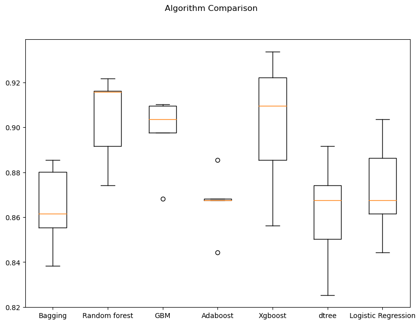

```python
fig = plt.figure(figsize=(10, 7))

fig.suptitle("Algorithm Comparison")
ax = fig.add_subplot(111)

plt.boxplot(results1)
ax.set_xticklabels(names)

plt.show()
```

## Observaciones

> Observaciones de los Modelos con Datos Submuestreados:
- Entrenamiento:

Random Forest muestra el rendimiento más alto con un recall de 0.9039. GBM y XGBoost le siguen de cerca con recalls de 0.8979 y 0.9015, respectivamente.

- Validación:

En el conjunto de validación, XGBoost toma la delantera con un recall de 0.8957. Random Forest y GBM también muestran un rendimiento sólido en validación, con recalls de 0.8921 y 0.8885, respectivamente. Consistencia en el Rendimiento:

A diferencia de los datos sobremuestreados, la diferencia entre el rendimiento de entrenamiento y validación para la mayoría de los modelos es menor con datos submuestreados. Esto sugiere una mejor generalización. La Regresión Logística muestra un rendimiento consistentemente bueno en ambos conjuntos, lo que es notable dado su rendimiento en los otros conjuntos de datos.

## Elección de modelos

Después de revisar detenidamente el rendimiento de varios modelos en diferentes conjuntos de datos (originales, sobremuestreados y submuestreados), he decidido trabajar más a fondo con los siguientes modelos:

- XGBoost (set de datos originales)
- Random Forest (set de datos submuestreados)
- GBM (Gradient Boosting Machine) (set de datos submuestreados)
- AdaBoost (set de datos sobremuestreados)

¿Por qué?

Originalmente, estaba considerando incluir el modelo Bagging debido a su rendimiento en algunos conjuntos de datos. Sin embargo, decidí optar por AdaBoost en lugar de Bagging. Mi razón principal para este cambio es que aunque ambos modelos tienen sus fortalezas, la técnica de "boosting" de AdaBoost puede complementar a los otros modelos basados en árboles y, con el ajuste adecuado, maximizar nuestro objetivo principal: maximizar el recall y así, identificar con precisión las fallas del generador.

## Sintonización de hiperparámetros

### Muestras de cuadrículas de parámetros

**El ajuste de hiperparámetros puede tardar mucho tiempo en ejecutarse, así que para evitar esa complejidad de tiempo, puede utilizar las siguientes cuadrículas, cuando sea necesario.**

- Para Gradient Boosting:

param_grid = { "n_estimators": np.arange(100,150,25), "learning_rate": [0.2, 0.05, 1], "subsample":[0.5,0.7], "max_features":[0.5,0.7] }

- Para Adaboost:

param_grid = { "n_estimators": [100, 150, 200], "learning_rate": [0.2, 0.05], "base_estimator": [DecisionTreeClassifier(max_depth=1, random_state=1), DecisionTreeClassifier(max_depth=2, random_state=1), DecisionTreeClassifier(max_depth=3, random_state=1), ] }

- Para Bagging Classifier:

param_grid = { 'max_samples': [0.8,0.9,1], 'max_features': [0.7,0.8,0.9], 'n_estimators' : [30,50,70], }

- Para Random Forest:

param_grid = { "n_estimators": [200,250,300], "min_samples_leaf": np.arange(1, 4), "max_features": [np.arange(0.3, 0.6, 0.1),'sqrt'], "max_samples": np.arange(0.4, 0.7, 0.1) }

- Para Decision Trees:

param_grid = { 'max_depth': np.arange(2,6), 'min_samples_leaf': [1, 4, 7], 'max_leaf_nodes' : [10, 15], 'min_impurity_decrease': [0.0001,0.001] }

- Para Logistic Regression:

param_grid = {'C': np.arange(0.1,1.1,0.1)}

- Para XGBoost:

param_grid={ 'n_estimators': [150, 200, 250], 'scale_pos_weight': [5,10], 'learning_rate': [0.1,0.2], 'gamma': [0,3,5], 'subsample': [0.8,0.9] }

### Ajuste de Hiperparametros para AdaBoost usando data sobremuestreada

```python
%%time

# defining model
Model = AdaBoostClassifier(random_state=1)

# Parameter grid to pass in RandomSearchCV
param_grid = {
    "n_estimators": [100, 150, 200],
    "learning_rate": [0.2, 0.05],
    "base_estimator": [DecisionTreeClassifier(max_depth=1, random_state=1), DecisionTreeClassifier(max_depth=2, random_state=1), DecisionTreeClassifier(max_depth=3, random_state=1),
    ]
}


#Calling RandomizedSearchCV
randomized_cv = RandomizedSearchCV(estimator=Model, param_distributions=param_grid, n_iter=50, n_jobs = -1, scoring=scorer, cv=5, random_state=1)

#Fitting parameters in RandomizedSearchCV
randomized_cv.fit(X_train_over,y_train_over)

print("Best parameters are {} with CV score={}:" .format(randomized_cv.best_params_,randomized_cv.best_score_))
```

```
Best parameters are {'n_estimators': 200, 'learning_rate': 0.2, 'base_estimator': DecisionTreeClassifier(max_depth=3, random_state=1)} with CV score=0.971555946263926:
CPU times: total: 1min 37s
Wall time: 7min 33s
```

```python
# Creating new pipeline with best parameters
tuned_ada = AdaBoostClassifier(
    n_estimators= 200, learning_rate= 0.2, base_estimator= DecisionTreeClassifier(max_depth=3, random_state=1)
)

tuned_ada.fit(X_train_over,y_train_over)
```

```
AdaBoostClassifier(base_estimator=DecisionTreeClassifier(max_depth=3,
                                                         random_state=1),
                   learning_rate=0.2, n_estimators=200)
```

```python
ada_train_perf = model_performance_classification_sklearn(tuned_ada, X_train_over, y_train_over)
ada_train_perf
```

|  | Accuracy | Recall | Precision | F1 |
| --- | --- | --- | --- | --- |
| 0 | 0.992 | 0.988 | 0.995 | 0.992 |

```python
ada_val_perf = model_performance_classification_sklearn(tuned_ada, X_val, y_val)
ada_val_perf
```

|  | Accuracy | Recall | Precision | F1 |
| --- | --- | --- | --- | --- |
| 0 | 0.979 | 0.853 | 0.790 | 0.820 |

### Observaciones

Tras ajustar los hiperparámetros de AdaBoost con datos sobremuestreados, el modelo mostró un rendimiento estelar en el entrenamiento, con una precisión del 99.2% y un recall del 98.8%. En validación, la precisión fue del 97.9% y el recall del 85.3%. Aunque hay una pequeña brecha entre el rendimiento de entrenamiento y validación, los resultados son prometedores. Podría ser útil equilibrar aún más el recall y la precisión en futuras iteraciones, pero en general, estoy satisfecho con estos resultados.

### Ajuste de Hiperparametros para Random forest usando datos submuestreados

```python
%%time

# defining model
Model = RandomForestClassifier(random_state=1)

# Parameter grid to pass in RandomSearchCV
param_grid = {
    "n_estimators": [200,250,300],
    "min_samples_leaf": np.arange(1, 4),
    "max_features": [np.arange(0.3, 0.6, 0.1),'sqrt'],
    "max_samples": np.arange(0.4, 0.7, 0.1)}


#Calling RandomizedSearchCV
randomized_cv = RandomizedSearchCV(estimator=Model, param_distributions=param_grid, n_iter=50, n_jobs = -1, scoring=scorer, cv=5, random_state=1)

#Fitting parameters in RandomizedSearchCV
randomized_cv.fit(X_train_un, y_train_un)

print("Best parameters are {} with CV score={}:" .format(randomized_cv.best_params_,randomized_cv.best_score_))
```

```
Best parameters are {'n_estimators': 300, 'min_samples_leaf': 2, 'max_samples': 0.5, 'max_features': 'sqrt'} with CV score=0.8990116153235697:
CPU times: total: 1.91 s
Wall time: 15.3 s
```

```python
# Creating new pipeline with best parameters
tuned_rf2 = RandomForestClassifier(
    max_features='sqrt',
    max_samples=0.5,
    n_estimators=300,
    min_samples_leaf=2,
    random_state=1,
)

tuned_rf2.fit(X_train_un, y_train_un)
```

```
RandomForestClassifier(max_samples=0.5, min_samples_leaf=2, n_estimators=300,
                       random_state=1)
```

```python
rf2_train_perf = model_performance_classification_sklearn(tuned_rf2, X_train_un, y_train_un)
rf2_train_perf
```

|  | Accuracy | Recall | Precision | F1 |
| --- | --- | --- | --- | --- |
| 0 | 0.961 | 0.933 | 0.989 | 0.960 |

```python
rf2_val_perf = model_performance_classification_sklearn(tuned_rf2, X_val, y_val)
rf2_val_perf
```

|  | Accuracy | Recall | Precision | F1 |
| --- | --- | --- | --- | --- |
| 0 | 0.938 | 0.885 | 0.468 | 0.612 |

### Observaciones

Después de ajustar los hiperparámetros de Random Forest en datos submuestreados, observé un rendimiento sólido en el entrenamiento con una precisión del 96.1% y un recall del 93.3%. Sin embargo, en el conjunto de validación, aunque la precisión sigue siendo alta (93.8%), el recall es del 88.5%. Es notable la baja precisión del 46.8% en validación, lo que impacta en una puntuación F1 de 61.2%.

### Ajuste de Hiperparametros para Gradient Boosting usando data submuestreada

```python
%%time

# defining model
Model = GradientBoostingClassifier(random_state=1)

#Parameter grid to pass in RandomSearchCV
param_grid={"n_estimators": np.arange(100,150,25), "learning_rate": [0.2, 0.05, 1], "subsample":[0.5,0.7], "max_features":[0.5,0.7]}

#Calling RandomizedSearchCV
randomized_cv = RandomizedSearchCV(estimator=Model, param_distributions=param_grid, scoring=scorer, n_iter=50, n_jobs = -1, cv=5, random_state=1)

#Fitting parameters in RandomizedSearchCV
randomized_cv.fit(X_train_un, y_train_un)

print("Best parameters are {} with CV score={}:" .format(randomized_cv.best_params_,randomized_cv.best_score_))
```

```
Best parameters are {'subsample': 0.7, 'n_estimators': 125, 'max_features': 0.5, 'learning_rate': 0.2} with CV score=0.9050212827357333:
CPU times: total: 1.34 s
Wall time: 12.5 s
```

```python
# Creating new pipeline with best parameters
tuned_gbm = GradientBoostingClassifier(
    max_features=0.5,
    random_state=1,
    learning_rate=0.2,
    n_estimators=125,
    subsample=0.7,
)

tuned_gbm.fit(X_train_un, y_train_un)
```

```
GradientBoostingClassifier(learning_rate=0.2, max_features=0.5,
                           n_estimators=125, random_state=1, subsample=0.7)
```

```python
gbm_train_perf = model_performance_classification_sklearn(tuned_gbm, X_train_un, y_train_un)
gbm_train_perf
```

|  | Accuracy | Recall | Precision | F1 |
| --- | --- | --- | --- | --- |
| 0 | 0.995 | 0.990 | 1.000 | 0.995 |

```python
gbm_val_perf = model_performance_classification_sklearn(tuned_gbm, X_val, y_val)
gbm_val_perf
```

|  | Accuracy | Recall | Precision | F1 |
| --- | --- | --- | --- | --- |
| 0 | 0.923 | 0.881 | 0.412 | 0.561 |

### Observaciones

Luego de optimizar los hiperparámetros de Gradient Boosting en datos submuestreados, se obtuvo un rendimiento casi perfecto en el entrenamiento, con una precisión y F1 del 99.5%, y un recall del 99.0%. Sin embargo, al evaluar en el conjunto de validación, a pesar de mantener un recall robusto de 88.1%, la precisión disminuyó drásticamente a 41.2%, lo que resultó en una puntuación F1 de 56.1%.

### Ajuste de Hiperparametros para XGBoost usando data original

```python
%%time

# defining model
Model = XGBClassifier(random_state=1,eval_metric='logloss')

#Parameter grid to pass in RandomSearchCV
param_grid={'n_estimators':[150,200,250],'scale_pos_weight':[5,10], 'learning_rate':[0.1,0.2], 'gamma':[0,3,5], 'subsample':[0.8,0.9]}

#Calling RandomizedSearchCV
randomized_cv = RandomizedSearchCV(estimator=Model, param_distributions=param_grid, n_iter=50, n_jobs = -1, scoring=scorer, cv=5, random_state=1)

#Fitting parameters in RandomizedSearchCV
randomized_cv.fit(X_train, y_train)

print("Best parameters are {} with CV score={}:" .format(randomized_cv.best_params_,randomized_cv.best_score_))
```

```
Best parameters are {'subsample': 0.8, 'scale_pos_weight': 10, 'n_estimators': 200, 'learning_rate': 0.2, 'gamma': 5} with CV score=0.8582136930957363:
CPU times: total: 5.61 s
Wall time: 31.7 s
```

```python
xgb2 = XGBClassifier(
    random_state=1,
    eval_metric="logloss",
    subsample=0.8,
    scale_pos_weight=10,
    n_estimators=200,
    learning_rate=0.2,
    gamma=5,
)

xgb2.fit(X_train, y_train)
```

```
XGBClassifier(base_score=None, booster=None, callbacks=None,
              colsample_bylevel=None, colsample_bynode=None,
              colsample_bytree=None, device=None, early_stopping_rounds=None,
              enable_categorical=False, eval_metric='logloss',
              feature_types=None, gamma=5, grow_policy=None,
              importance_type=None, interaction_constraints=None,
              learning_rate=0.2, max_bin=None, max_cat_threshold=None,
              max_cat_to_onehot=None, max_delta_step=None, max_depth=None,
              max_leaves=None, min_child_weight=None, missing=nan,
              monotone_constraints=None, multi_strategy=None, n_estimators=200,
              n_jobs=None, num_parallel_tree=None, random_state=1, ...)
```

```python
xgb2_train_perf =  model_performance_classification_sklearn(xgb2, X_train, y_train)
xgb2_train_perf
```

|  | Accuracy | Recall | Precision | F1 |
| --- | --- | --- | --- | --- |
| 0 | 0.999 | 1.000 | 0.974 | 0.987 |

```python
xgb2_val_perf =  model_performance_classification_sklearn(xgb2, X_val, y_val)
xgb2_val_perf
```

|  | Accuracy | Recall | Precision | F1 |
| --- | --- | --- | --- | --- |
| 0 | 0.987 | 0.849 | 0.911 | 0.879 |

### Observaciones

Tras ajustar los hiperparámetros de XGBoost usando los datos originales, el modelo demostró un rendimiento excepcional en el conjunto de entrenamiento, alcanzando una precisión del 99.9%, un recall perfecto de 100% y una puntuación F1 del 98.7%. En el conjunto de validación, la precisión fue del 98.7%, con un robusto recall del 84.9% y una precisión de 91.1%, lo que llevó a una puntuación F1 de 87.9%. Estos resultados indican que el modelo no sólo se ajusta bien a los datos de entrenamiento, sino que también generaliza eficazmente a nuevos datos, manteniendo un equilibrio entre recall y precisión.

## Comparación del rendimiento del modelo y elección del modelo final

```python
# training performance comparison

models_train_comp_df = pd.concat(
    [
        gbm_train_perf.T,
        ada_train_perf.T,
        rf2_train_perf.T,
        xgb2_train_perf.T,
    ],
    axis=1,
)
models_train_comp_df.columns = [
    "Gradient Boosting tuned with undersampled data",
    "AdaBoost classifier tuned with oversampled data",
    "Random forest tuned with undersampled data",
    "XGBoost tuned with original data",
]
print("Training performance comparison:")
models_train_comp_df
```

```
Training performance comparison:
```

|  | Gradient Boosting tuned with undersampled data | AdaBoost classifier tuned with oversampled data | Random forest tuned with undersampled data | XGBoost tuned with original data |
| --- | --- | --- | --- | --- |
| Accuracy | 0.995 | 0.992 | 0.961 | 0.999 |
| Recall | 0.990 | 0.988 | 0.933 | 1.000 |
| Precision | 1.000 | 0.995 | 0.989 | 0.974 |
| F1 | 0.995 | 0.992 | 0.960 | 0.987 |

```python
# validation performance comparison

models_val_comp_df = pd.concat(
    [
        gbm_val_perf.T,
        ada_val_perf.T,
        rf2_val_perf.T,
        xgb2_val_perf.T,
    ],
    axis=1,
)
models_val_comp_df.columns = [
    "Gradient Boosting tuned with undersampled data",
    "AdaBoost classifier tuned with oversampled data",
    "Random forest tuned with undersampled data",
    "XGBoost tuned with original data",
]
print("Validation performance comparison:")
models_val_comp_df
```

```
Validation performance comparison:
```

|  | Gradient Boosting tuned with undersampled data | AdaBoost classifier tuned with oversampled data | Random forest tuned with undersampled data | XGBoost tuned with original data |
| --- | --- | --- | --- | --- |
| Accuracy | 0.923 | 0.979 | 0.938 | 0.987 |
| Recall | 0.881 | 0.853 | 0.885 | 0.849 |
| Precision | 0.412 | 0.790 | 0.468 | 0.911 |
| F1 | 0.561 | 0.820 | 0.612 | 0.879 |

### Observaciones

- Rendimiento en el Set de Entrenamiento:

Todos los modelos muestran un rendimiento muy cercano en términos de precisión, recall, precisión y F1. Sin embargo, XGBoost destaca ligeramente en términos de recall con un perfecto 100%.

- Rendimiento en el Set de Validación:

En términos de precisión (accuracy), XGBoost lidera con un 98.7%, seguido de cerca por AdaBoost con un 97.9%. En cuanto a recall, el modelo Random Forest tiene la puntuación más alta con 88.5%, lo cual es crucial dado que estamos priorizando esta métrica. En precisión, XGBoost lidera con 91.1%. La métrica F1, que combina precisión y recall, es liderada por XGBoost con 87.9%, seguido de cerca por AdaBoost con 82.0%.

- Conclusiones:

XGBoost tiene un rendimiento impresionante, especialmente en el set de entrenamiento con un recall del 100%. Sin embargo, en el set de validación, aunque sigue siendo robusto, está ligeramente por detrás de Random Forest en términos de recall. AdaBoost muestra un equilibrio sólido entre todas las métricas en el set de validación, especialmente en precisión y F1. Random Forest destaca en términos de recall en el set de validación, lo cual es nuestra métrica prioritaria. Gradient Boosting tiene un buen rendimiento, pero en comparación con los otros modelos, sus métricas en el set de validación están un poco por detrás.

### Rendimiento final del conjunto de pruebas

```python
rf2_under_test_perf = model_performance_classification_sklearn(
    tuned_rf2, X_test, y_test)

print("Test performance:")
rf2_under_test_perf
```

```
Test performance:
```

|  | Accuracy | Recall | Precision | F1 |
| --- | --- | --- | --- | --- |
| 0 | 0.944 | 0.879 | 0.500 | 0.638 |

### Observaciones

Tras aplicar el modelo Random Forest con datos submuestreados al conjunto de prueba, se obtuvieron los siguiebtes resultados. La precisión (accuracy) del modelo es del 94.4%, lo que indica un rendimiento sólido en términos de predicciones generales. El recall, nuestra métrica prioritaria, se sitúa en el 87.9%, lo que sugiere que el modelo es eficiente al identificar fallas del generador.

Sin embargo, es importante señalar la precisión del 50%. Esta métrica más baja sugiere que el modelo está prediciendo más falsos positivos, es decir, está identificando fallas donde no las hay. Esto queda reflejado en la métrica F1, que es del 63.8%, mostrando el desequilibrio entre precisión y recall.

En resumen, el modelo Random Forest con datos submuestreados sigue siendo eficaz en la identificación de fallas reales, como se refleja en el alto recall. Sin embargo, la precisión más baja en el conjunto de prueba sugiere que es recomendable revisar y considerar los costos asociados a los falsos positivos

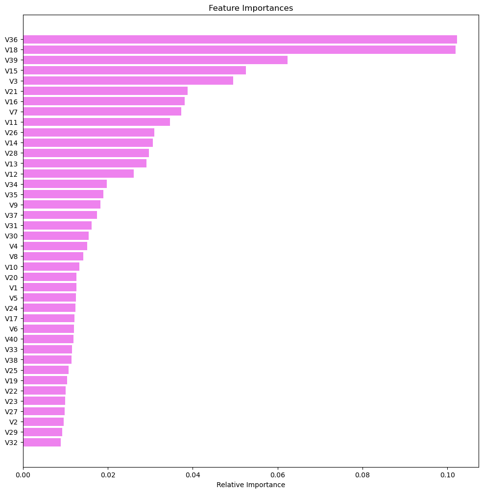

```python
feature_names = X_train.columns
importances =  tuned_rf2.feature_importances_ ## Complete the code to check the feature importance of the best model
indices = np.argsort(importances)

plt.figure(figsize=(12, 12))
plt.title("Feature Importances")
plt.barh(range(len(indices)), importances[indices], color="violet", align="center")
plt.yticks(range(len(indices)), [feature_names[i] for i in indices])
plt.xlabel("Relative Importance")
plt.show()
```

Es esencial entender más a fondo qué representan específicamente las variables más influyentes en términos de sensores o factores ambientales. Al hacerlo, se pueden tomar decisiones más informadas en la operación real y el mantenimiento de las turbinas eólicas.

## Pipelines para construir el modelo final

```python
Model = Pipeline([('imputer', SimpleImputer()), ('rf2', RandomForestClassifier(
    max_features='sqrt',
    random_state=1,
    max_samples=0.5,
    n_estimators=300,
    min_samples_leaf=2,
))])
```

```python
# Separating target variable and other variables
X1 = data.drop(columns="Target")
Y1 = data["Target"]


X_test1 = df_test.drop(["Target"], axis=1)
y_test1 = df_test["Target"]
```

```python
imputer = SimpleImputer(strategy="median")
X1 = imputer.fit_transform(X1)
```

```python
rus = RandomUnderSampler(random_state=1, sampling_strategy=1)
X_train_un, y_train_un = rus.fit_resample(X_train, y_train)
```

```python
Model.fit(X_train, y_train) #ajuste de modelo final
```

```
Pipeline(steps=[('imputer', SimpleImputer()),
                ('rf2',
                 RandomForestClassifier(max_samples=0.5, min_samples_leaf=2,
                                        n_estimators=300, random_state=1))])
```

```python
Pipeline_model_test = model_performance_classification_sklearn(
    Model, X_test, y_test)
Pipeline_model_test
```

|  | Accuracy | Recall | Precision | F1 |
| --- | --- | --- | --- | --- |
| 0 | 0.980 | 0.645 | 0.989 | 0.781 |

### Observaciones

En resumen, el modelo muestra una alta precisión y un buen balance en la métrica F1, pero es esencial considerar el recall más bajo al pensar en su aplicación en un contexto real, ya que podría haber algunas fallas no detectadas.

# Perspectivas y conclusiones comerciales

- Recomendaciones de Negocio:

Monitoreo Continuo: Es crucial seguir monitoreando las variables más influyentes, y comprender su significado real para anticipar y actuar rápidamente ante posibles fallas.

Optimizar el Recall: Aunque hemos logrado buenos resultados, el recall es una métrica clave. Es importante continuar trabajando en la mejora del modelo para identificar todas las posibles fallas y evitar costosos reemplazos.

Revisión de Falsos Positivos: Dada la alta precisión del modelo, debemos estar atentos a no incurrir en inspecciones innecesarias. Es esencial equilibrar el costo de inspección con el de reparación o reemplazo.

Capacitación Continua: A medida que implementamos estos modelos avanzados, es vital que todo el equipo entienda su funcionamiento y significado. Una formación regular puede ayudar a alinear a todos con nuestra visión predictiva.